# Jupyter Notebooks

## Curve fitting

We have already seen that we can fit polynomial functions through a data set using the `numpy.polyfit` function. Here, we introduce a more generic curve fitting algorithm.

Scipy provides a somewhat generic function (based on the Levenburg-Marquardt algorithm )through `scipy.optimize.curve_fit` to fit a given (Python) function to a given data set. The assumption is that we have been given a set of data with points $x_1, x_2, …x_N$ and with corresponding function values $y_i$ and a dependence of $y_i$ on $x_i$ such that $y_i=f(x_i,\vec{p})$. We want to determine the parameter vector $\vec{p}=(p_1, p_2, \ldots, p_k)$ so that $r$, the sum of the residuals, is as small as possible:

$$r = \sum\limits_{i=1}^N \left(y_i - f(x_i, \vec{p})\right)^2$$

Curve fitting is of particular use if the data is noisy: for a given $x_i$ and $y_i=f(x_i,\vec{p})$ we have a (unknown) error term $\epsilon_i$ so that $y_i=f(x_i,\vec{p})+\epsilon_i$.

We use the following example to clarify this: $$f(x,\vec{p}) = a \exp(-b x) + c, \quad\mathrm{i.e.}\quad \vec{p}=\mathtt{a,b,c}$$

```
Optimal parameters are a=2.524, b=1.04295, and c=0.378715
```

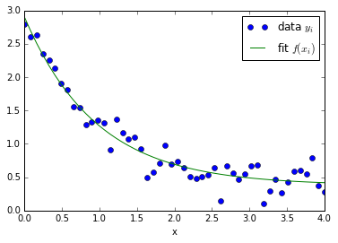

```python
import numpy as np
from scipy.optimize import curve_fit


def f(x, a, b, c):
    """Fit function y=f(x,p) with parameters p=(a,b,c). """
    return a * np.exp(- b * x) + c

#create fake data
x = np.linspace(0, 4, 50)
y = f(x, a=2.5, b=1.3, c=0.5)
#add noise
yi = y + 0.2 * np.random.normal(size=len(x))

#call curve fit function
popt, pcov = curve_fit(f, x, yi)
a, b, c = popt
print("Optimal parameters are a=%g, b=%g, and c=%g" % (a, b, c))

#plotting
import pylab
yfitted = f(x, *popt)   # equivalent to f(x, popt[0], popt[1], popt[2])
pylab.plot(x, yi, 'o', label='data $y_i$')
pylab.plot(x, yfitted, '-', label='fit $f(x_i)$')
pylab.xlabel('x')
pylab.legend()
```

Note that in the source code above we define the fitting function $y = f(x)$ through Python code. We can thus fit (nearly) arbitrary functions using the `curve_fit` method.

For the curve fitting process to work, the Levenburg-Marquardt algorithm needs to start the fitting process with initial guesses for the final parameters. If these are not specified (as in the example above), the value “1.0“ is used for the initial guess.

If the algorithm fails to fit a function to data (even though the function describes the data reasonably), we need to give the algorithm better estimates for the initial parameters. For the example shown above, we could give the estimates to the `curve_fit` function by changing the line

```
popt, pcov = curve_fit(f, x, yi)
```

to

```
popt, pcov = curve_fit(f, x, yi, p0=(2,1,0.6))
```

if our initial guesses would be *a* = 2, *b* = 1 and *c* = 0.6. Once we take the algorithm “roughly in the right area” in parameter space, the fitting usually works well.

## Fourier transforms

In the next example, we create a signal as a superposition of a 50 Hz and 70 Hz sine wave (with a slight phase shift between them). We then Fourier transform the signal and plot the absolute value of the (complex) discrete Fourier transform coefficients against frequency, and expect to see peaks at 50Hz and 70Hz.

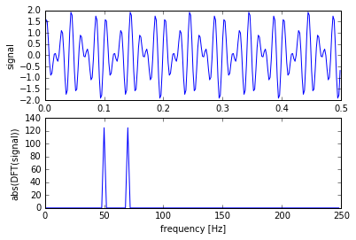

```python
import scipy
import matplotlib.pyplot as plt
pi = scipy.pi

signal_length = 0.5   #[seconds]
sample_rate=500       #sampling rate [Hz]
dt = 1./sample_rate   #time between two samples [s]

df = 1/signal_length  #frequency between points in
                      #in frequency domain [Hz]
t=scipy.arange(0,signal_length,dt) #the time vector
n_t=len(t)            #length of time vector

#create signal
y=scipy.sin(2*pi*50*t)+scipy.sin(2*pi*70*t+pi/4)

#compute fourier transform
f=scipy.fft(y)

#work out meaningful frequencies in fourier transform
freqs=df*scipy.arange(0,(n_t-1)/2.,dtype='d') #d=double precision float
n_freq=len(freqs)

#plot input data y against time
plt.subplot(2,1,1)
plt.plot(t,y,label='input data')
plt.xlabel('time [s]')
plt.ylabel('signal')

#plot frequency spectrum
plt.subplot(2,1,2)
plt.plot(freqs,abs(f[0:n_freq]),
         label='abs(fourier transform)')
plt.xlabel('frequency [Hz]')
plt.ylabel('abs(DFT(signal))')
```

The lower plot shows the discrete Fourier transform computed from the data shown in the upper plot.

## Optimisation

Often we need to find the maximum or minimum of a particular function *f*(*x*) where *f* is a scalar function but *x* could be a vector. Typical applications are the minimisation of entities such as cost, risk and error, or the maximisation of productivity, efficiency and profit. Optimisation routines typically provide a method to minimise a given function: if we need to maximise *f*(*x*) we create a new function *g*(*x*) that reverses the sign of *f*, i.e. *g*(*x*)= − *f*(*x*) and we minimise *g*(*x*).

Below, we provide an example showing (i) the definition of the test function and (ii) the call of the `scipy.optimize.fmin` function which takes as argument a function *f* to minimise and an initial value *x*<sub>0</sub> from which to start the search for the minimum, and which returns the value of *x* for which *f*(*x*) is (locally) minimised. Typically, the search for the minimum is a local search, i.e. the algorithm follows the local gradient. We repeat the search for the minimum for two values (*x*<sub>0</sub> = 1.0 and *x*<sub>0</sub> = 2.0, respectively) to demonstrate that depending on the starting value we may find different minimar of the function *f*.

The majority of the commands (after the two calls to `fmin`) in the file `fmin1.py` creates the plot of the function, the start points for the searches and the minima obtained:

```
Optimization terminated successfully.
         Current function value: -2.023866
         Iterations: 16
         Function evaluations: 32
Start search at x=1., minimum is [ 0.23964844]
Optimization terminated successfully.
         Current function value: -1.000529
         Iterations: 16
         Function evaluations: 32
Start search at x=2., minimum is [ 3.13847656]
```

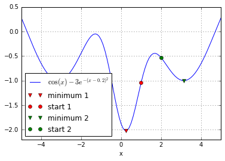

```python
from scipy import arange, cos, exp
from scipy.optimize import fmin
import pylab

def f(x):
    return cos(x) - 3 * exp( -(x - 0.2) ** 2)

# find minima of f(x),
# starting from 1.0 and 2.0 respectively
minimum1 = fmin(f, 1.0)
print("Start search at x=1., minimum is", minimum1)
minimum2 = fmin(f, 2.0)
print("Start search at x=2., minimum is", minimum2)

# plot function
x = arange(-10, 10, 0.1)
y = f(x)
pylab.plot(x, y, label='$\cos(x)-3e^{-(x-0.2)^2}$')
pylab.xlabel('x')
pylab.grid()
pylab.axis([-5, 5, -2.2, 0.5])

# add minimum1 to plot
pylab.plot(minimum1, f(minimum1), 'vr',
           label='minimum 1')
# add start1 to plot
pylab.plot(1.0, f(1.0), 'or', label='start 1')

# add minimum2 to plot
pylab.plot(minimum2,f(minimum2),'vg',\
           label='minimum 2')
# add start2 to plot
pylab.plot(2.0,f(2.0),'og',label='start 2')

pylab.legend(loc='lower left')
```

Calling the `fmin` function will produce some diagnostic output, which you can also see above.

##### Return value of `fmin`

Note that the return value from the `fmin` function is a numpy `array` which – for the example above – contains only one number as we have only one parameter (here *x*) to vary. In general, `fmin` can be used to find the minimum in a higher-dimensional parameter space if there are several parameters. In that case, the numpy array would contain those parameters that minimise the objective function. The objective function $f(x)$ has to return a scalar even if there are more parameters, i.e. even if $x$ is a vector as in $f(\mathbf{x})$.

## Other numerical methods

Scientific Python and Numpy provide access to a large number of other numerical algorithms including function interpolation, Fourier transforms, optimisation, special functions (such as Bessel functions), signal processing and filters, random number generation, and more. Start to explore `scipy`’s and `numpy`’s capabilities using the `help` function and the documentation provided on the web.

## scipy.io: Scipy-input output

Scipy provides routines to read and write Matlab `mat` files. Here is an example where we create a Matlab compatible file storing a (1x11) matrix, and then read this data into a numpy array from Python using the scipy Input-Output library:

First we create a mat file in Octave (Octave is [mostly] compatible with Matlab):

```
octave:1> a=-1:0.5:4
a =
Columns 1 through 6:
   -1.0000   -0.5000    0.0000    0.5000    1.0000    1.5000
Columns 7 through 11:
   2.0000    2.5000   3.0000    3.5000    4.0000
octave:2> save -6 octave_a.mat a       %save as version 6
```

Then we load this array within python:

```python
from scipy.io import loadmat
mat_contents = loadmat('scipy/code/octave_a.mat')
```

```python
mat_contents
```

```
{'__globals__': [],
 '__header__': b'MATLAB 5.0 MAT-file Platform: posix, Created on: Mon Aug  8 12:21:36 2016',
 '__version__': '1.0',
 'a': array([[-1. , -0.5,  0. ,  0.5,  1. ,  1.5,  2. ,  2.5,  3. ,  3.5,  4. ]])}
```

```python
mat_contents['a']
```

```
array([[-1. , -0.5,  0. ,  0.5,  1. ,  1.5,  2. ,  2.5,  3. ,  3.5,  4. ]])
```

A Matlab matrix file can hold several arrays. Each of those is presented by one key-value pair in the dictionary.

Let’s save two arrays from Python to demonstrate that:

```python
import scipy.io
import numpy as np

# create two numpy arrays
a = np.linspace(0, 50, 11)
b = np.ones((4, 4))

# save as mat-file
# create dictionary for savemat
tmp_d = {'a': a,
         'b': b}
scipy.io.savemat('data.mat', tmp_d)
```

This program creates the file `data.mat`, which we can subsequently read using Matlab or here Octave:

```
HAL47:code fangohr$ octave
GNU Octave, version 3.2.4
Copyright (C) 2009 John W. Eaton and others.
<snip>

octave:1> whos
Variables in the current scope:

  Attr Name        Size                     Bytes  Class
  ==== ====        ====                     =====  =====
       ans         1x11                        92  cell

Total is 11 elements using 92 bytes

octave:2> load data.mat
octave:3> whos
Variables in the current scope:

  Attr Name        Size                     Bytes  Class
  ==== ====        ====                     =====  =====
       a          11x1                         88  double
       ans         1x11                        92  cell
       b           4x4                        128  double

Total is 38 elements using 308 bytes

octave:4> a
a =

    0
    5
   10
   15
   20
   25
   30
   35
   40
   45
   50

octave:5> b
b =

   1   1   1   1
   1   1   1   1
   1   1   1   1
   1   1   1   1
```

Note that there are other functions to read from and write to in formats as used by IDL, Netcdf and other formats in `scipy.io`.

More → see [Scipy tutorial](http://docs.scipy.org/doc/scipy/reference/tutorial/io.html).

# Symbolic Math (symy)

`sympy` is a symbolic maths library for Python. `sympy` can be installed using either `pip` or `conda`, but is shiped with the Anaconda distribution of Python.

```
import sympy
help(sympy)
```

```
Help on package sympy:

NAME
    sympy

DESCRIPTION
    SymPy is a Python library for symbolic mathematics. It aims to become a
    full-featured computer algebra system (CAS) while keeping the code as simple
    as possible in order to be comprehensible and easily extensible.  SymPy is
    written entirely in Python. It depends on mpmath, and other external libraries
    may be optionally for things like plotting support.

    See the pngage for more information and documentation:

        http://sympy.org
```

## Symbols

Symbols are what `sympy` calls algebraic variables that are used in your mathematical expressions.

```python
from sympy import symbols
x,y = symbols('x y')
print(2*x + y)
type(x+y/2)
```

```
2*x + y
```

```
sympy.core.add.Add
```

The symbols are not "normal" Python numeric variables. As can be seen Python did not attempt to perform an arithmetic operation on x and y but creates an algebraic expression.

The `sympy.abc` module can be used to export predefined symbols, making your code a little neater:

```python
from sympy.abc import x, y
print(x**2 + 2*x + y)
(x**2 + 2*x + y).evalf(subs={x:5,y:2})
```

```
x**2 + 2*x + y
```

$\displaystyle 37.0$

Note that `sympy` algebraic expressions follow the same conventions as Python arithmetic. For example: `2*x` and not `2x`, `x**2` and not `x^2`.

## Algebra

Expand products and powers

Expand ($(x+y)^2 (x+1)$) :

```python
from sympy import init_printing
init_printing()
((x+y)**2 * (x+1)).expand()
```

$\displaystyle x^{3} + 2 x^{2} y + x^{2} + x y^{2} + 2 x y + y^{2}$

Simplify a formula

Simplify ( $\frac{1}{x} + \frac{x \sin x - 1}{x}$) :

```python
from sympy import sin, simplify
a = 1/x + (x*sin(x) - 1)/x
simplify(a)
```

$\displaystyle \sin{\left(x \right)}$

Solve a polynomial equation

Find the roots of ( $x^3 + 2x^2 + 4x + 8$) :

```python
from sympy import solve, Eq
solve(Eq(x**3 + 2*x**2 + 4*x + 8, 0), x)
```

$\displaystyle \left[ -2, \ - 2 i, \ 2 i\right]$

or more easily:

```python
solve(x**3 + 2*x**2 + 4*x + 8, x)
```

$\displaystyle \left[ -2, \ - 2 i, \ 2 i\right]$

For details, see: Finding roots of polynomials. Solve an equation system

Solve the equation system ( $(x+5y=2, -3x+6y=15$)) :

```python
solve([Eq(x + 5*y, 2), Eq(-3*x + 6*y, 15)], [x, y])
```

$\displaystyle \left\{ x : -3, \ y : 1\right\}$

or

```python
solve([x + 5*y - 2, -3*x + 6*y - 15], [x, y])
```

$\displaystyle \left\{ x : -3, \ y : 1\right\}$

Solve a recurrence relation

Solve: $$ { y }{ 0 }=1,\quad { y }{ 1 }=4,\quad { y }{ n }=2{ y }{ n-1 }+5{ y }_{ n-2 } $$

```python
from sympy import Function, var
f = Function('f')
y = Function('y')
```

```python
var('n',integer=True)
```

$\displaystyle n$

```python
from sympy import rsolve
f = y(n)-2*y(n-1)-5*y(n-2)
rsolve(f,y(n),[1,4])
```

$\displaystyle \left(\frac{1}{2} - \frac{\sqrt{6}}{4}\right) \left(1 - \sqrt{6}\right)^{n} + \left(\frac{1}{2} + \frac{\sqrt{6}}{4}\right) \left(1 + \sqrt{6}\right)^{n}$

Calculate a sum

Evaluate ( $\sum_{n=a}^b 6 n^2 + 2^n$) :

```python
from sympy import Sum
a, b = symbols('a b')
s = Sum(6*n**2 + 2**n, (n, a, b))
```

```python
Sum(2**n + 6*n**2, (n, a, b))
s.doit()
```

$\displaystyle - 2^{a} + 2^{b + 1} - 2 a^{3} + 3 a^{2} - a + 2 b^{3} + 3 b^{2} + b$

Calculate a product

Evaluate ( $\prod_{n=1}^b n (n+1)$) :

```python
from sympy import product
product(n*(n+1), (n, 1, b))
```

$\displaystyle {2}^{\left(b\right)} b!$

Solve a functional equation

Example: if $f\left( \frac { 1 }{ x } \right) -3f\left( x \right)=x$ then find $f\left( 2 f\right( ) $:

```python
f=Function('f')
ex=Eq(f(1/x)-3*f(x),x)
ex.subs(x,2)
```

$\displaystyle f{\left(\frac{1}{2} \right)} - 3 f{\left(2 \right)} = 2$

Or $f(1/2) - 3*f(2) == 2$

```python
from sympy import Rational
ex.subs(x,Rational(1,2))
```

$\displaystyle - 3 f{\left(\frac{1}{2} \right)} + f{\left(2 \right)} = \frac{1}{2}$

```python
solve([f(Rational(1,2))-3*f(2)-2,-3*f(Rational(1,2))+f(2)-Rational(1,2)])
```

$\displaystyle \left[ \left\{ f{\left(\frac{1}{2} \right)} : - \frac{7}{16}, \ f{\left(2 \right)} : - \frac{13}{16}\right\}\right]$

### evalf

[output not shown]

[output not shown]

$\displaystyle 0.5$

```python
Float(1/2,5)
```

$\displaystyle 0.5$

```python
Rational(1/2)
```

$\displaystyle \frac{1}{2}$

```python
from sympy import N, GoldenRatio, I
N(GoldenRatio**2) # same as evalf()
```

$\displaystyle 2.61803398874989$

```python
type(I)
```

```
sympy.core.numbers.ImaginaryUnit
```

```python
y = var('y')
```

```python
x + I*y
```

$\displaystyle x + i y$

## Differentiation and Integration

Calculate a limit

Evaluate ( $\lim_{x\to 0} \frac{\sin x - x}{x^3}$) :

```python
from sympy import limit
limit((sin(x)-x)/x**3, x, 0)
```

$\displaystyle - \frac{1}{6}$

Calculate a Taylor series

Find the Maclaurin series of ( $\frac{1}{\cos x}) up to the ( O(x^6)$) term:

```python
from sympy import cos
(1/cos(x)).series(x, 0, 6)
```

$\displaystyle 1 + \frac{x^{2}}{2} + \frac{5 x^{4}}{24} + O\left(x^{6}\right)$

Calculate a derivative

Differentiate ( $\frac{\cos(x^2)^2}{1+x}$) :

```python
from sympy import diff
diff(cos(x**2)**2 / (1+x), x)
```

$\displaystyle - \frac{4 x \sin{\left(x^{2} \right)} \cos{\left(x^{2} \right)}}{x + 1} - \frac{\cos^{2}{\left(x^{2} \right)}}{\left(x + 1\right)^{2}}$

Calculate an integral

Calculate the indefinite integral ( $\int x^2 \cos x , dx$)

```python
from sympy import integrate
integrate(x**2 * cos(x), x)
```

$\displaystyle x^{2} \sin{\left(x \right)} + 2 x \cos{\left(x \right)} - 2 \sin{\left(x \right)}$

Calculate the definite integral ( $\int_0^{\pi/2} x^2 \cos x , dx$) :

```python
from sympy import pi
integrate(x**2 * cos(x), (x, 0, pi/2))
```

$\displaystyle -2 + \frac{\pi^{2}}{4}$

### Solve an ordinary differential equation

Solve ( $f''(x) + 9 f(x) = 1$) :

```python
from sympy import Derivative, dsolve
f = Function('f')
dsolve(Eq(Derivative(f(x),x,x) + 9*f(x), 1), f(x))
```

$\displaystyle f{\left(x \right)} = C_{1} \sin{\left(3 x \right)} + C_{2} \cos{\left(3 x \right)} + \frac{1}{9}$

You can also use .diff(), like here (an example in isympy)

```python
f = Function("f")
Eq(f(x).diff(x, x) + 9*f(x), 1)
```

$\displaystyle 9 f{\left(x \right)} + \frac{d^{2}}{d x^{2}} f{\left(x \right)} = 1$

```python
dsolve(_, f(x))
```

$\displaystyle f{\left(x \right)} = C_{1} \sin{\left(3 x \right)} + C_{2} \cos{\left(3 x \right)} + \frac{1}{9}$